# Demonstração IFOOD

*Esse é um projeto de demonstração de features de I.A.*

*Foram aplicadas as técnicas de Clusterização, Classificação e Analise de Sentimento em 3 bases de amostra*

```python
import pandas as pd
import plotly.offline as py
import plotly.graph_objs as go
import csv
from wordcloud import WordCloud
py.init_notebook_mode(connected=True)
import matplotlib.pyplot as plt
import matplotlib.image as mpimg
```

## Clusterização das Amostras

*Nessa estapa aplicamos a técnica de clusterização para que possamos identificar tendências de reviews na base de dados*

### Amostra 1

#### Cluster 1

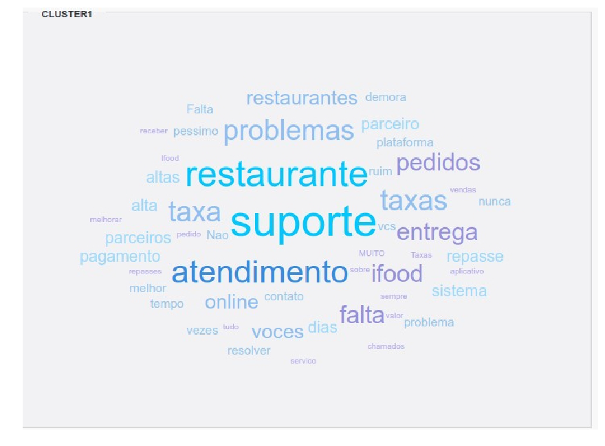

```python
img=mpimg.imread('cluster1-amostra1.jpg')
imgplot=plt.imshow(img)

fig_size = []
fig_size.append(30)
fig_size.append(30)

plt.rcParams["figure.figsize"]=fig_size
plt.axis('off')
plt.show()
```

#### Cluster 2

[figure not shown]

```python
img=mpimg.imread('cluster2-amostra1.jpg')
imgplot=plt.imshow(img)

fig_size = []
fig_size.append(30)
fig_size.append(30)

plt.rcParams["figure.figsize"]=fig_size
plt.axis('off')
plt.show()
```

### Amostra 2

#### Cluster 1

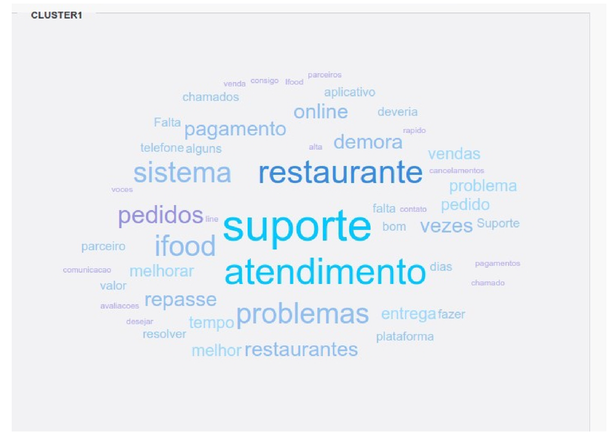

```python
img=mpimg.imread('cluster1-amostra2.jpg')
imgplot=plt.imshow(img)

fig_size = []
fig_size.append(30)
fig_size.append(30)

plt.rcParams["figure.figsize"]=fig_size
plt.axis('off')
plt.show()
```

#### Cluster 2

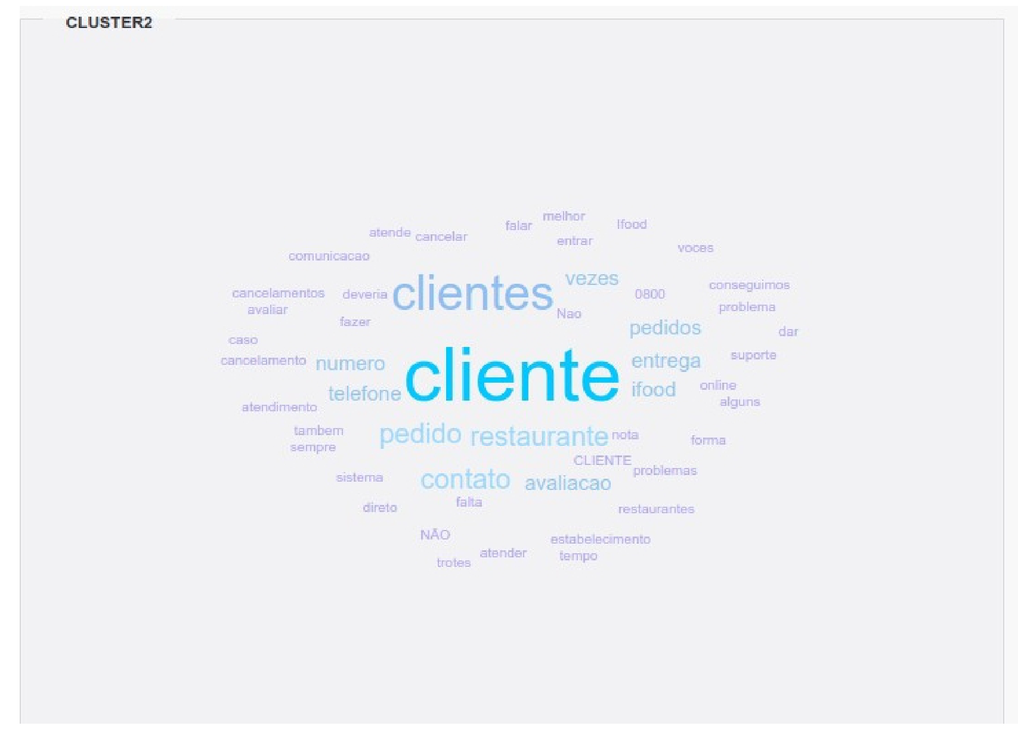

```python
img=mpimg.imread('cluster2-amostra2.jpg')
imgplot=plt.imshow(img)

fig_size = []
fig_size.append(20)
fig_size.append(20)

plt.rcParams["figure.figsize"]=fig_size
plt.axis('off')
plt.show()
```

#### Cluster 3

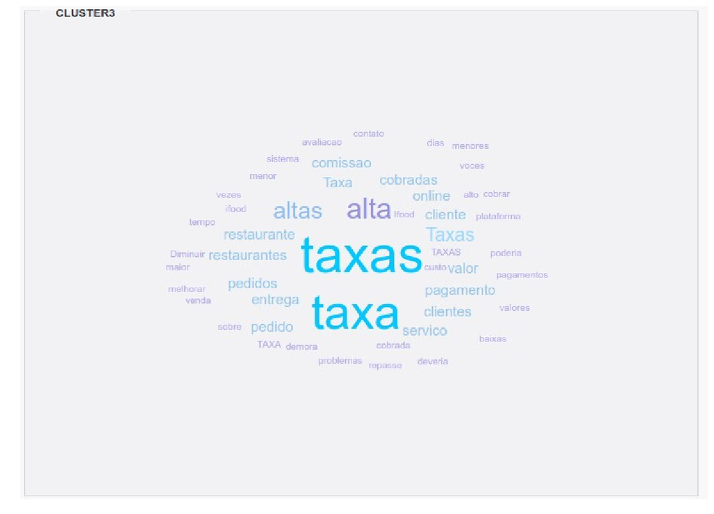

```python
img=mpimg.imread('cluster3-amostra2.jpg')
imgplot=plt.imshow(img)

fig_size = []
fig_size.append(10)
fig_size.append(10)

plt.rcParams["figure.figsize"]=fig_size
plt.axis('off')
plt.show()
```

### Amostra 3

#### Cluster 1

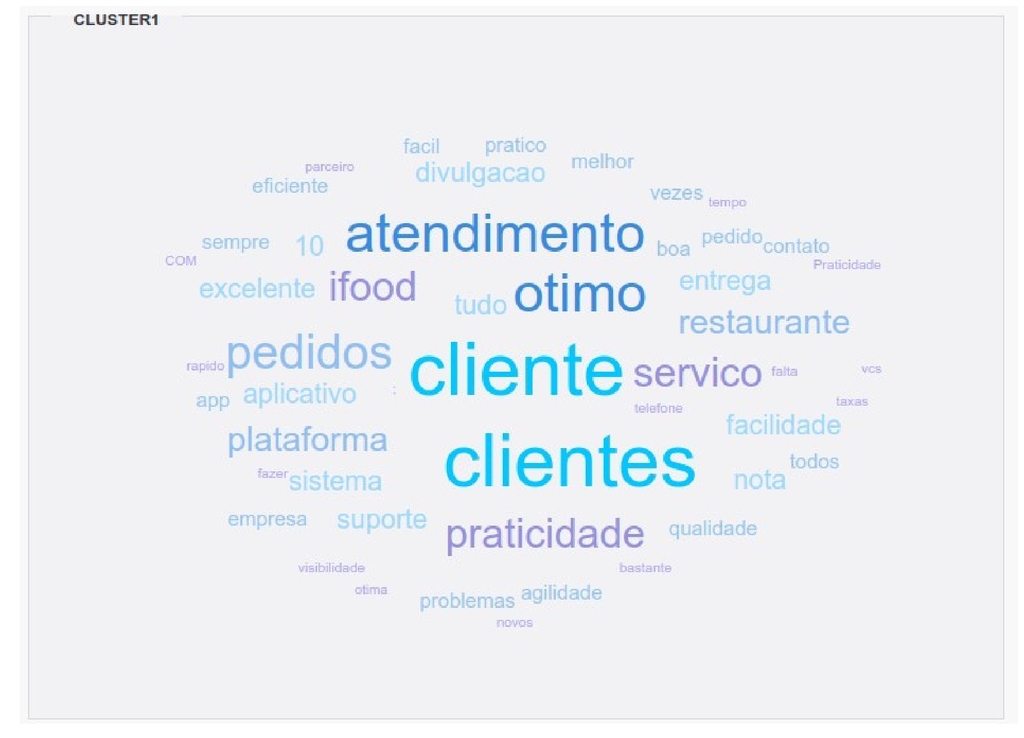

```python
img=mpimg.imread('cluster1-amostra3.jpg')
imgplot=plt.imshow(img)

fig_size = []
fig_size.append(30)
fig_size.append(30)

plt.rcParams["figure.figsize"]=fig_size
plt.axis('off')
plt.show()
```

#### Cluster 2

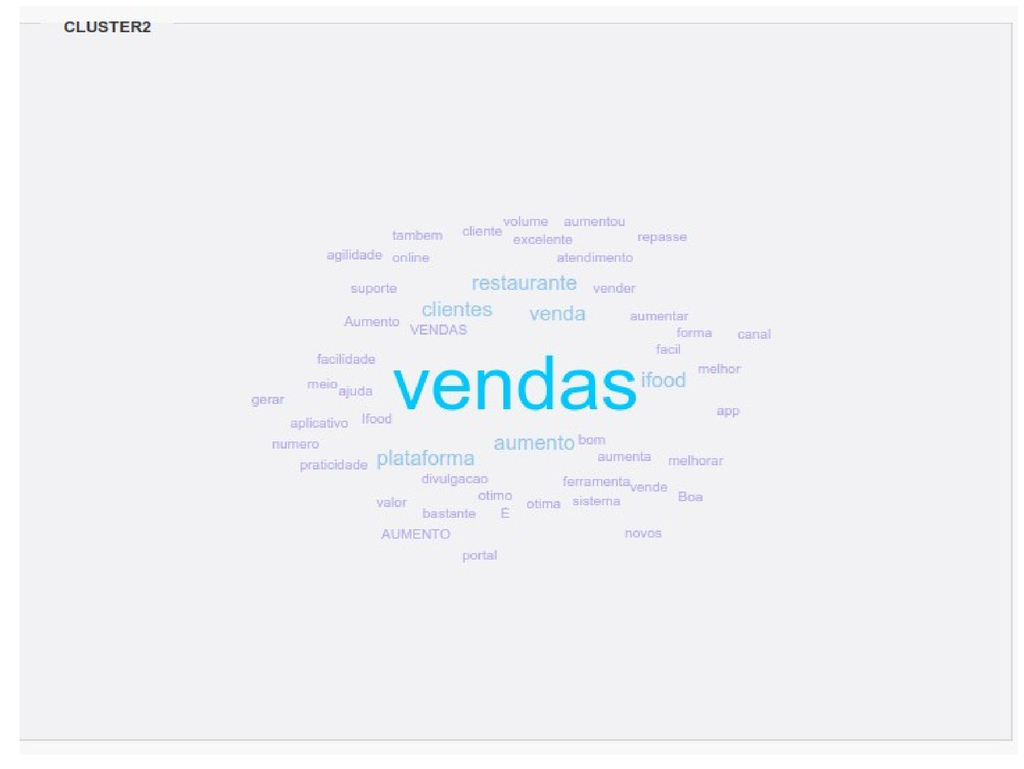

```python
img=mpimg.imread('cluster2-amostra3.jpg')
imgplot=plt.imshow(img)

fig_size = []
fig_size.append(15)
fig_size.append(15)

plt.rcParams["figure.figsize"]=fig_size
plt.axis('off')
plt.show()
```

## Categorização dos Reviews

*Para para realizar a classificação das bases de dados separamos os reviews em 5 grupos diferentes:*

- 1- Sistema: Reviews que se referem a funcionalidades no sistema, utilização, ou bugs
- 2- Serviço de Entrega: Reviews que se referem a entregas de produtos do aplicativo
- 3- Taxas: Reviews que se referem as valores das taxas cobras pelo/no aplicativo
- 4- Pagamento: Reviews que se referem aos pagamentos dos restaurantes/lanchonetes pelo IFOOD
- 5- Atendimento: Reviews que se referem ao antendimento do suporte, ou SAC do IFOOD

*Nessa etapa as amostras foram submetidas a um algoritmo de classificação com o objetivo de identificar em quais das 5 grupos identificadas o review pertence*

```python
list_good = []
list_bad = []
list_arq = ['dados1.csv','dados2.csv','dados3.csv']
labels = ['Sistema','Serviço de Entrega','Taxas','Pagamento','Atendimento']
flag = True


for arq in list_arq:
    with open(arq) as file:
        readCsv = csv.reader(file)
        for row in readCsv:
            if flag:
                list_good.append(row[0:5])
                flag = False
            else:
                list_bad.append(row[0:5])
                flag = True
```

```python
list_total_categ = []

for ind in range(len(list_good)):
    categ = []
    categ.append(int(list_good[ind][0])+int(list_bad[ind][0]))
    categ.append(int(list_good[ind][1])+int(list_bad[ind][1]))
    categ.append(int(list_good[ind][2])+int(list_bad[ind][2]))
    categ.append(int(list_good[ind][3])+int(list_bad[ind][3]))
    categ.append(int(list_good[ind][4])+int(list_bad[ind][4]))
    list_total_categ.append(categ)
```

### Amostra 1

```python
graph = go.Bar(x = labels,
                y = list_total_categ[0],name = 'Positivo',
                marker = {'color': 'blue'})
data = [graph]
py.iplot(data)
```

[interactive chart not shown]

### Amostra 2

```python
graph = go.Bar(x = labels,
                y = list_total_categ[1],name = 'Positivo',
                marker = {'color': 'blue'})
data = [graph]
py.iplot(data)
```

[interactive chart not shown]

### Amostra 3

```python
graph = go.Bar(x = labels,
                y = list_total_categ[2],name = 'Positivo',
                marker = {'color': 'blue'})
data = [graph]
py.iplot(data)
```

[interactive chart not shown]

## Análise de Sentimento dos Reviews

*Após separarmos as bases de dados em 5 grupos aplicamos a análise de sentimento nesses grupos para identificarmos como está a satisfação em relação a cada grupo*

### Amostra 1

```python
graph_good = go.Bar(x = labels,
                y = list_good[0],name = 'Positivo',
                marker = {'color': '#2e7d32'})
graph_bad = go.Bar(x = labels,
                y = list_bad[0],name = 'Negativo',
                marker = {'color': '#e53935'})

data = [graph_good, graph_bad]
py.iplot(data)
```

[interactive chart not shown]

### Amostra 2

```python
graph_good = go.Bar(x = labels,
                y = list_good[1],name = 'Positivo',
                marker = {'color': '#2e7d32'})
graph_bad = go.Bar(x = labels,
                y = list_bad[1],name = 'Negativo',
                marker = {'color': '#e53935'})

data = [graph_good, graph_bad]
py.iplot(data)
```

[interactive chart not shown]

### Amostra 3

```python
graph_good = go.Bar(x = labels,
                y = list_good[2],name = 'Positivo',
                marker = {'color': '#2e7d32'})
graph_bad = go.Bar(x = labels,
                y = list_bad[2],name = 'Negativo',
                marker = {'color': '#e53935'})

data = [graph_good, graph_bad]
py.iplot(data)
```

[interactive chart not shown]

## Conclusão

*Com esse projeto de demostração conseguimos concluir que :*

### Amostra 1

- Com a clusterização observamos que os termos que mais presentes nas reviews são:
  - Suporte
  - Atendimento
  - Cliente
- Na categorização observamos que realmente os grupos que possuem mais reviews nesse base são:
  - 1°- Sistema : Onde normalmente é comentado sobre funcionalidades que os clientes realizam
  - 2°- Atendimento: Onde os termos suporte e atendimento se encontram
- Na análise de sentimentos podemos identificar o nível de satifação onde:
  - Grupo Atendimento possue 97% dos reviews sendo negativos
  - Grupo Sistema possue 79% dos reviews sendo negativos

### Amostra 2

- Com a clusterização observamos que os termos mais presentes nas reviews são:
  - Suporte
  - Atendimento
  - Cliente
  - Taxa
- Na categorização observamos que os grupos com mais relevância nessa base são:
  - 1°- Sistema : Onde normalmente é comentado sobre funcionalidades que os clientes realizam
  - 2°- Atendimento: Onde os termos suporte e atendimento se encontram
  - 3°- Taxa: Onde o termo taxa se encontra
- Na análise de sentimentos podemos identificar o nível de satifação onde:
  - Grupo Taxa possue 95% dos reviews sendo negativos
  - Grupo Atendimento possue 93% dos reviews sendo negativos
  - Grupo Sistema possue 79% dos reviews sendo negativos

### Amostra 3

- Com a clusterização observamos que os termos mais presentes nas reviews são:
  - Cliente
  - Venda
- Na categorização observamos que o grupo com mais relevância nessa base é:
  - Sistema : Onde normalmente é comentado sobre funcionalidades que os clientes realizam e processo de venda
- Na análise de sentimentos podemos identificar o nível de satifação onde:
  - Grupo Sistema possue 66% dos reviews sendo positivos